# Ford GoBike System Data Exploration

## by Omar Abuhassan

## Dataset Overview

> This data set includes information about individual rides made in a bike-sharing system covering the greater San Francisco Bay area.

## The average duration of trips

> usually trip take between 500 and 650 sec.

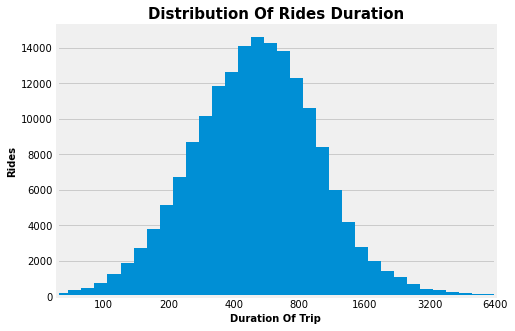

## Is Start time affect the duration of the trip?

> On average users may have longer trip when they start between 11 AM and 4 PM.

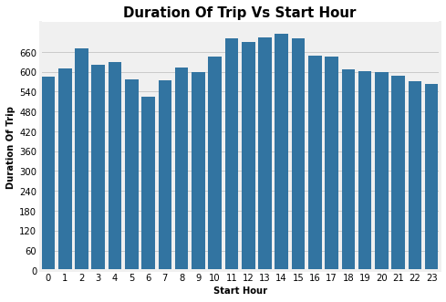

## What is combination of user type and gender has the highest duration average ?

> Female customers have the highest average time trip and male subscribers have the lowest one.

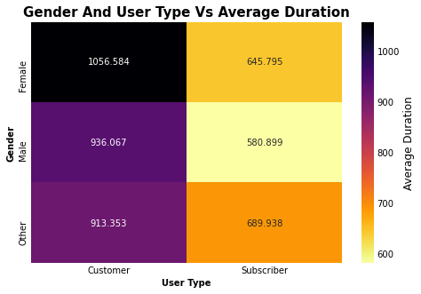

## Is there a diffrence between genders in tearms of average duration and age ?

> Generally females using bike more thean males. Moreover, both Males and Females have stable duration trip time with slightly inceasing when they are between age 48 and 60. However, I think because of small sample of Others the line related to them is not that stable.

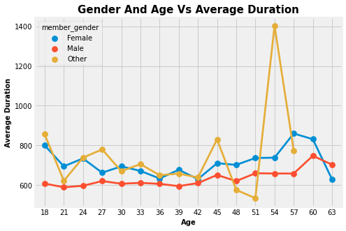

## Which gender is more likely to subscribe with our servecies ?

> Male are more likely to subscribe with our servecies than females.

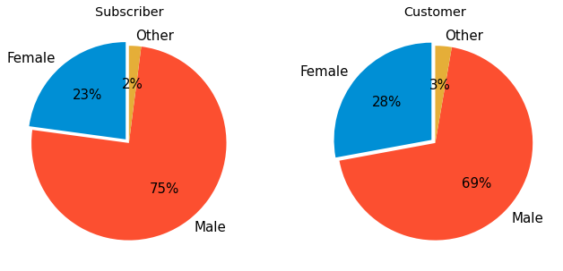

## Is there a diffrence between user type in tearms of average age and starting hour ?

> There is no big different between customers and subscribers in terms of start time.

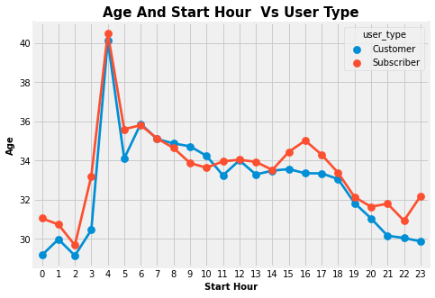